# Bioconductor

## Setup

```r
# # install Bioconductor
# if (!require("BiocManager", quietly = TRUE))
# install.packages("BiocManager")
# BiocManager::install(version = "3.17")  # version 3.17 compatible with R4.3
#
# ## list Bioconductor packages
# bpkgs <- c("GEOquery","org.Mm.eg.db","GenomeInfoDbData","TxDb.Mmusculus.UCSC.mm10.knownGene","Mus.musculus","BiocStyle","limma","edgeR","RColorBrewer","gplots","gage","clusterProfiler","ReactomePA","GOSemSim","DOSE","enrichplot","getGEOSuppFiles")
#
# # install Bioconductor packages
# BiocManager::install(bpkgs, force = TRUE)
# BiocManager::install("org.Mm.eg.db", force = TRUE)
#
# ## list CRAN packages
# rpkgs <- c("ggplot2","here","cli","R.utils","rmarkdown","knitr","utf8")
# # install CRAN packages
# install.packages(rpkgs)
```

### Libraries

```r
library(GEOquery)
library(edgeR)
library(org.Mm.eg.db)
library(RColorBrewer)
```

## Data

Retrieve the raw RNA-seq files using the GEO accession number for our dataset (GSE63310). These are usually provided in plan text files. This function `getGEOSuppFiles()` will detect the format. We will call this object `gse` which stands for GEO Series (GSE) and is used as an acronym used by the NCBI GEO repository.

```r
projdir <- "~/rtdatasci_github/R/bioconductor/"
setwd(projdir)

#?getGEOSuppFiles
gse <- getGEOSuppFiles(GEO = "GSE63310", baseDir=paste0(projdir, "data"))
```

unzip the folder alternatively, can use tar -xf in terminal command

```r
untar(tarfile=paste0(projdir, "data", "/GSE63310/GSE63310_RAW.tar"),
      exdir=paste0(projdir, "data"))
```

### files list

analyzing 9 of the 11 samples (each sample is in a separate file). selecting the 9 primary cell types studied: *basal* cells, *luminal progenitor (LP)* cells, and *mature luminal-enriched (ML)* cells. Each cell type has 3 samples. store the corresponding cell types in another character vector called `celltypes`.

```r
files <- c("GSM1545535_10_6_5_11.txt", ## LP
           "GSM1545536_9_6_5_11.txt",  ## ML
           "GSM1545538_purep53.txt",   ## basal
           "GSM1545539_JMS8-2.txt",    ## basal
           "GSM1545540_JMS8-3.txt",    ## ML
           "GSM1545541_JMS8-4.txt",    ## LP
           "GSM1545542_JMS8-5.txt",    ## basal
           "GSM1545544_JMS9-P7c.txt",  ## ML
           "GSM1545545_JMS9-P8c.txt")  ## LP
celltypes <- c("LP", "ML", "Basal", "Basal", "ML", "LP", "Basal", "ML", "LP")
```

### Unpack and decompress files

unzip the files one by one so we can look at them. Since there are only 9 we can use a for loop (if you have a lot more files or very large files, then you may want to use some more efficient method).

```r
# commented out for the purpose of knitting because unzip done during test

# setwd(paste0(projdir, "data/GSE63310"))
# for(f in paste(files, ".gz", sep="")) {
#     gunzip(paste0(projdir, "data/GSE63310/", f), overwrite=TRUE)
#}
```

This is a data frame with three columns: the gene ID (ENTREZID), length of the gene, and read counts from the run.

```r
setwd(paste0(projdir, "data/GSE63310"))


files[1]
```

```
## [1] "GSM1545535_10_6_5_11.txt"
```

```r
f1 <- read.delim(files[1])
dim(f1)
```

```
## [1] 27179     3
```

```r
head(f1)
```

```
##    EntrezID GeneLength Count
## 1    497097       3634     1
## 2 100503874       3259     0
## 3 100038431       1634     0
## 4     19888       9747     0
## 5     20671       3130     1
## 6     27395       4203   431
```

```r
tail(f1)
```

```
##        EntrezID GeneLength Count
## 27174 100504460       3540     0
## 27175 100861837       2794   320
## 27176 100861924        250    15
## 27177    170942        777   824
## 27178 100861691        745     0
## 27179 100504472       3540     0
```

### Create a digital gene expression (DGE) object

create a `DGEList` object which will contain data from all 9 files. This requires us to indicate which columns represent the gene names and raw read counts. This assumes there is only one gene per row (no duplicates).

```r
projdir <- "~/rtdatasci_github/R/bioconductor/"
setwd(projdir)

#?readDGE
dge <- readDGE(files = files, path=paste0(projdir, "data/GSE63310/"),
               columns = c(1,3), ## column 1 has the genes, column 3 has the counts
               group = celltypes)
dge
```

```
## An object of class "DGEList"
## $samples
##                                         files group lib.size norm.factors
## GSM1545535_10_6_5_11 GSM1545535_10_6_5_11.txt    LP 32863052            1
## GSM1545536_9_6_5_11   GSM1545536_9_6_5_11.txt    ML 35335491            1
## GSM1545538_purep53     GSM1545538_purep53.txt Basal 57160817            1
## GSM1545539_JMS8-2       GSM1545539_JMS8-2.txt Basal 51368625            1
## GSM1545540_JMS8-3       GSM1545540_JMS8-3.txt    ML 75795034            1
## GSM1545541_JMS8-4       GSM1545541_JMS8-4.txt    LP 60517657            1
## GSM1545542_JMS8-5       GSM1545542_JMS8-5.txt Basal 55086324            1
## GSM1545544_JMS9-P7c   GSM1545544_JMS9-P7c.txt    ML 21311068            1
## GSM1545545_JMS9-P8c   GSM1545545_JMS9-P8c.txt    LP 19958838            1
##
## $counts
##            Samples
## Tags        GSM1545535_10_6_5_11 GSM1545536_9_6_5_11 GSM1545538_purep53
##   497097                       1                   2                342
##   100503874                    0                   0                  5
##   100038431                    0                   0                  0
##   19888                        0                   1                  0
##   20671                        1                   1                 76
##            Samples
## Tags        GSM1545539_JMS8-2 GSM1545540_JMS8-3 GSM1545541_JMS8-4
##   497097                  526                 3                 3
##   100503874                 6                 0                 0
##   100038431                 0                 0                 0
##   19888                     0                17                 2
##   20671                    40                33                14
##            Samples
## Tags        GSM1545542_JMS8-5 GSM1545544_JMS9-P7c GSM1545545_JMS9-P8c
##   497097                  535                   2                   0
##   100503874                 5                   0                   0
##   100038431                 1                   0                   0
##   19888                     0                   1                   0
##   20671                    98                  18                   8
## 27174 more rows ...
```

## Annotation

```r
dge_ids <- rownames(dge)
length(dge_ids) ## find out how many genes are represented
```

```
## [1] 27179
```

annotate the data with gene SYMBOLS instead of ENTREZIDs

```r
#?AnnotationDbi::select
gene_ids <- AnnotationDbi::select(org.Mm.eg.db,
    keys = dge_ids,
    keytype = "ENTREZID",
    columns = "SYMBOL")
head(gene_ids)
```

```
##    ENTREZID  SYMBOL
## 1    497097    Xkr4
## 2 100503874 Gm19938
## 3 100038431 Gm10568
## 4     19888     Rp1
## 5     20671   Sox17
## 6     27395  Mrpl15
```

add these identifiers to our dge count matrix by re-assigning the row names with SYMBOLs from our gene_ids object.

```r
rownames(dge$counts) <- gene_ids$SYMBOL
dge
```

```
## An object of class "DGEList"
## $samples
##                                         files group lib.size norm.factors
## GSM1545535_10_6_5_11 GSM1545535_10_6_5_11.txt    LP 32863052            1
## GSM1545536_9_6_5_11   GSM1545536_9_6_5_11.txt    ML 35335491            1
## GSM1545538_purep53     GSM1545538_purep53.txt Basal 57160817            1
## GSM1545539_JMS8-2       GSM1545539_JMS8-2.txt Basal 51368625            1
## GSM1545540_JMS8-3       GSM1545540_JMS8-3.txt    ML 75795034            1
## GSM1545541_JMS8-4       GSM1545541_JMS8-4.txt    LP 60517657            1
## GSM1545542_JMS8-5       GSM1545542_JMS8-5.txt Basal 55086324            1
## GSM1545544_JMS9-P7c   GSM1545544_JMS9-P7c.txt    ML 21311068            1
## GSM1545545_JMS9-P8c   GSM1545545_JMS9-P8c.txt    LP 19958838            1
##
## $counts
##          Samples
## Tags      GSM1545535_10_6_5_11 GSM1545536_9_6_5_11 GSM1545538_purep53
##   Xkr4                       1                   2                342
##   Gm19938                    0                   0                  5
##   Gm10568                    0                   0                  0
##   Rp1                        0                   1                  0
##   Sox17                      1                   1                 76
##          Samples
## Tags      GSM1545539_JMS8-2 GSM1545540_JMS8-3 GSM1545541_JMS8-4
##   Xkr4                  526                 3                 3
##   Gm19938                 6                 0                 0
##   Gm10568                 0                 0                 0
##   Rp1                     0                17                 2
##   Sox17                  40                33                14
##          Samples
## Tags      GSM1545542_JMS8-5 GSM1545544_JMS9-P7c GSM1545545_JMS9-P8c
##   Xkr4                  535                   2                   0
##   Gm19938                 5                   0                   0
##   Gm10568                 1                   0                   0
##   Rp1                     0                   1                   0
##   Sox17                  98                  18                   8
## 27174 more rows ...
```

## Expression

Calculate counts per million (CPM) and log-transform The cpm() function from the edgeR package calculates CPM values using the dge object that we have been working with. It can also calculate log2(CPM) values, which we will do by adding the log argument.

```r
#?cpm
cpm <- cpm(dge)
log2_cpm <- cpm(dge, log=TRUE)

head(log2_cpm)
```

```
##          Samples
## Tags      GSM1545535_10_6_5_11 GSM1545536_9_6_5_11 GSM1545538_purep53
##   Xkr4               -3.748623           -3.313765          2.5914607
##   Gm19938            -4.507432           -4.507432         -2.9275280
##   Gm10568            -4.507432           -4.507432         -4.5074315
##   Rp1                -4.507432           -3.790514         -4.5074315
##   Sox17              -3.748623           -3.790514          0.4579085
##   Mrpl15              3.717978            4.450445          4.5835457
##          Samples
## Tags      GSM1545539_JMS8-2 GSM1545540_JMS8-3 GSM1545541_JMS8-4
##   Xkr4             3.362285         -3.581259         -3.418282
##   Gm19938         -2.636931         -4.507432         -4.507432
##   Gm10568         -4.507432         -4.507432         -4.507432
##   Rp1             -4.507432         -1.898317         -3.698711
##   Sox17           -0.281645         -1.060843         -1.860900
##   Mrpl15           4.628091          4.370064          3.672539
##          Samples
## Tags      GSM1545542_JMS8-5 GSM1545544_JMS9-P7c GSM1545545_JMS9-P8c
##   Xkr4            3.2862891          -2.8591947           -4.507432
##   Gm19938        -2.8918170          -4.5074315           -4.507432
##   Gm10568        -4.0087883          -4.5074315           -4.507432
##   Rp1            -4.5074315          -3.4597175           -4.507432
##   Sox17           0.8663089          -0.1703963           -1.168797
##   Mrpl15          3.8965999           4.4597191            4.102594
```

distribution of each counts

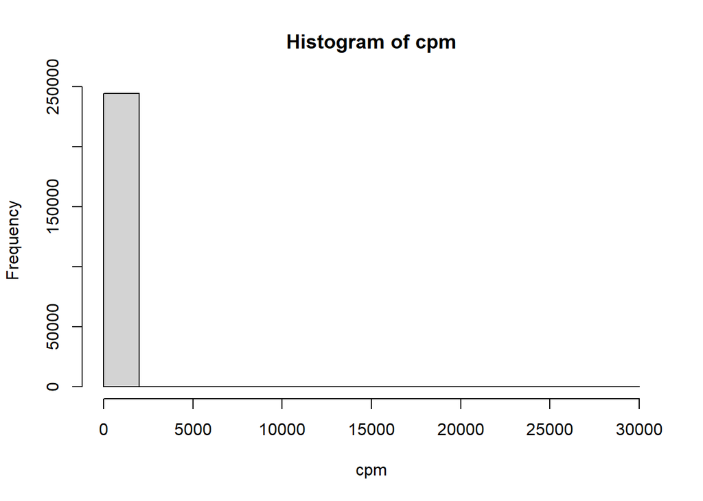

```r
hist(cpm)
```

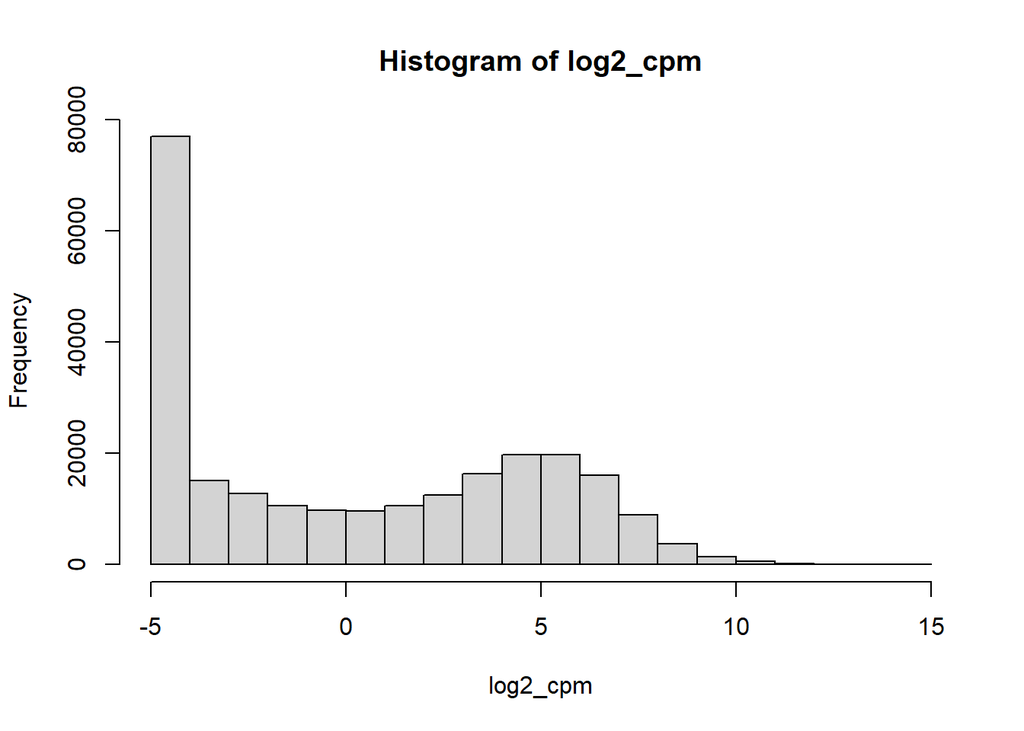

```r
#The log transformation just makes the non-0 values more normally distributed which can simplify statistical testing of differences between sample types
hist(log2_cpm)
```

### Filter and plot expression Filter out genes with low expression

```r
dim(dge)
```

```
## [1] 27179     9
```

```r
dge_sub <- dge[rowSums(cpm>1)>=3, ]
dim(dge_sub)
```

```
## [1] 14165     9
```

Compare filtered to unfiltered data. We’re only going to be using ~52% of the data

```r
100 * nrow(dge_sub) / nrow(dge)
```

```
## [1] 52.11744
```

assign different colors to each of the 9 samples so we can overlay them and be able to distinguish them from each other more easily.

```r
#?RColorBrewer

nsamples <- ncol(dge_sub) ## 9 samples
col <- brewer.pal(n = nsamples, name = "Paired") ## the paird option gives up to 12 distinct colors
col
```

```
## [1] "#A6CEE3" "#1F78B4" "#B2DF8A" "#33A02C" "#FB9A99" "#E31A1C" "#FDBF6F"
## [8] "#FF7F00" "#CAB2D6"
```

plot the log2(CPM) distributions for both raw and filtered data.

```r
log2cpm_raw <- cpm(dge, log=TRUE) ## raw unfiltered expression (log2 CPM)
log2cpm_sub <- cpm(dge_sub, log=TRUE) ## filtered
```

density() function from the stats package will give us the data to plot the raw and filtered data.

```r
density(log2cpm_raw[,1])
```

```
##
## Call:
##  density.default(x = log2cpm_raw[, 1])
##
## Data: log2cpm_raw[, 1] (27179 obs.); Bandwidth 'bw' = 0.5129
##
##        x                 y
##  Min.   :-6.0460   Min.   :3.300e-07
##  1st Qu.:-0.4591   1st Qu.:1.878e-03
##  Median : 5.1279   Median :4.078e-02
##  Mean   : 5.1279   Mean   :4.469e-02
##  3rd Qu.:10.7148   3rd Qu.:6.215e-02
##  Max.   :16.3018   Max.   :2.592e-01
```

```r
density(log2cpm_sub[,1])
```

```
##
## Call:
##  density.default(x = log2cpm_sub[, 1])
##
## Data: log2cpm_sub[, 1] (14165 obs.); Bandwidth 'bw' = 0.3697
##
##        x                 y
##  Min.   :-5.6164   Min.   :8.600e-07
##  1st Qu.:-0.2443   1st Qu.:2.395e-03
##  Median : 5.1279   Median :2.026e-02
##  Mean   : 5.1279   Mean   :4.649e-02
##  3rd Qu.:10.5000   3rd Qu.:8.668e-02
##  Max.   :15.8722   Max.   :1.508e-01
```

set up a plot with 2 side-by-side density plots. raw data on the left plot and the filtered data on the right (par() to put in left or right)

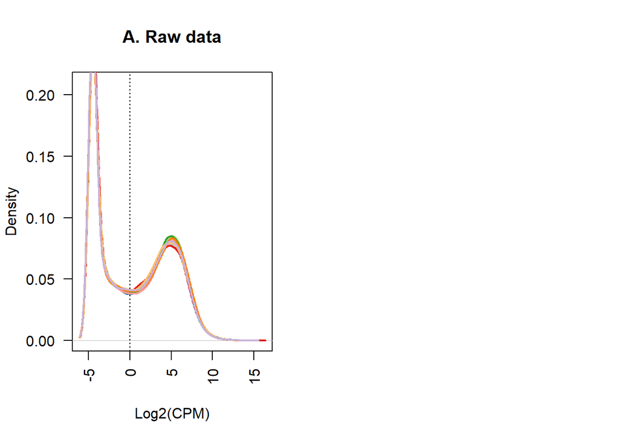

```r
par(mfrow=c(1,2))
plot(density(log2cpm_raw[,1]),
     col=col[1],
     lwd=2,
     ylim=c(0,0.21),
     las=2,
     main="",
     xlab="")
title(main="A. Raw data", xlab="Log2(CPM)")


abline(v=0, lty=3)

for (i in 2:nsamples){
    den <- density(log2cpm_raw[,i])
    lines(den$x, den$y, col=col[i], lwd=2)
}
```

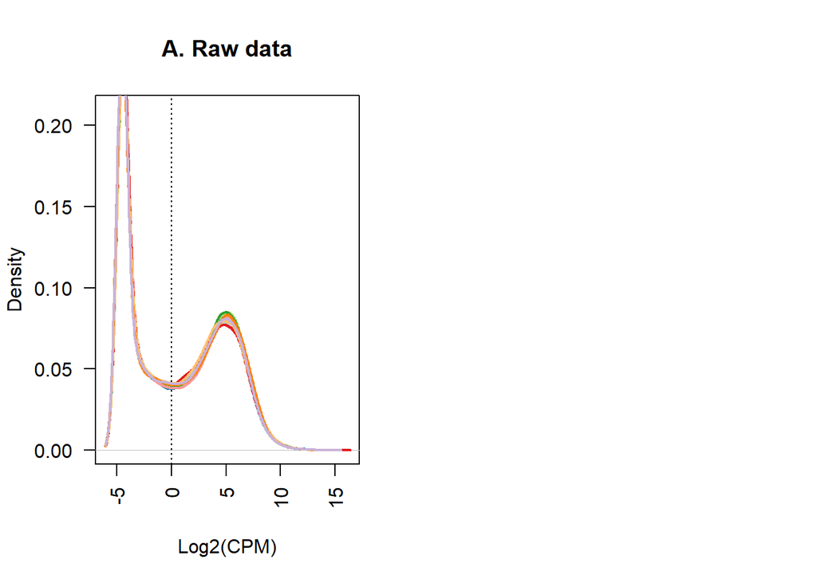

```r
par(mfrow=c(1,2))
plot(density(log2cpm_raw[,1]),
     col=col[1],
     lwd=2,
     ylim=c(0,0.21),
     las=2,
     main="",
     xlab="")
title(main="A. Raw data", xlab="Log2(CPM)")

abline(v=0, lty=3)

for (i in 2:nsamples){
    den <- density(log2cpm_raw[,i])
    lines(den$x, den$y, col=col[i], lwd=2)
}
```

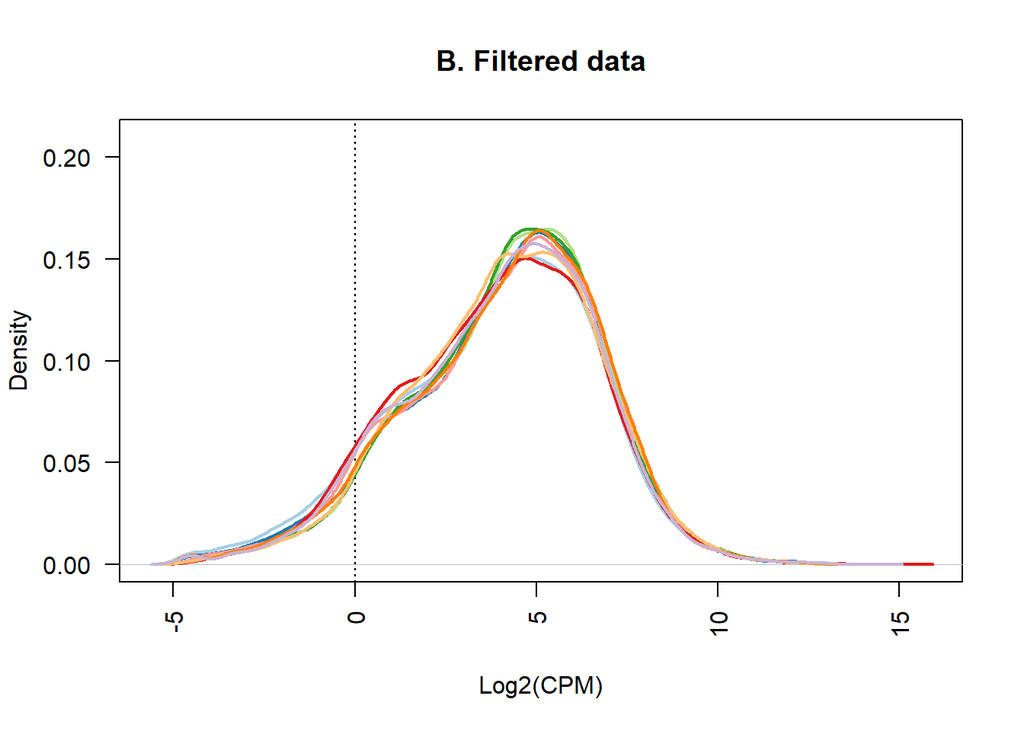

```r
plot(density(log2cpm_sub[,1]),
    col=col[1],
    lwd=2,
    ylim=c(0,0.21),
    las=2,
    main="",
    xlab="")
title(main="B. Filtered data", xlab="Log2(CPM)")
abline(v=0, lty=3)

for (i in 2:nsamples){
    den <- density(log2cpm_sub[,i])
    lines(den$x, den$y, col=col[i], lwd=2)
}
```